# BMI Calculator App

A Tool to Monitor Health

Henry Muhumuza

2024-12-13

# About the app

**BMI Calculator Shiny App**  
A web application to calculate and visualize BMI for better health monitoring.

# Problem Statement

Many individuals are unaware of their BMI or how it correlates to health risks.  
- Obesity and malnutrition are global health concerns.  
- Lack of easy-to-use tools for calculating and interpreting BMI.

# How the App Works

- The app allows users to input their weight and height.
- It calculates their BMI using the standard formula: BMI = weight(kg) / height(m)^2.
- A visualization is generated showing the BMI value relative to a normal distribution.
- Users can see if their BMI falls in a healthy range or indicates underweight/overweight status.

# Key Benefits

- **Easy-to-Use**: Simple input fields for weight and height.
- **Instant Feedback**: Shows BMI and a graphical representation.
- **Health Awareness**: Provides instant insight into whether the user’s BMI is within a healthy range, supporting better lifestyle choices.
- **Visual Data**: Displays the BMI value on a distribution curve to enhance understanding.

# BMI Distribution (Histogram)

Below is the histogram of BMI values with the global population mean BMI of **23.2** as per the World Health Organization:

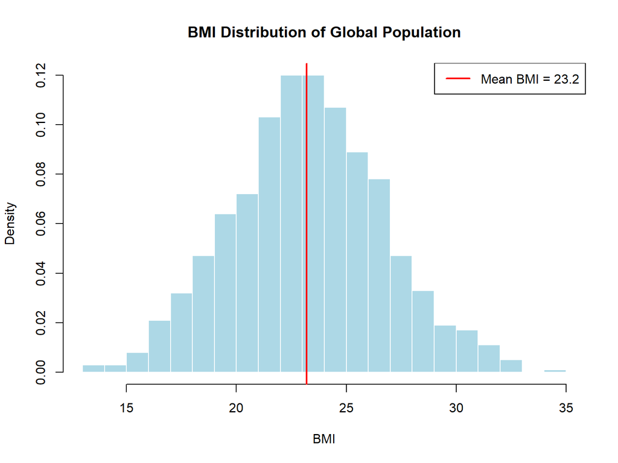